# Sparklines: Fifty-One State Trends in One Table

A table that is also fifty-one charts

Democracy’s Data

Last updated September 13, 2026 at 10:53a EDT

Every election night ends with a sentence about movement. The country swung four points, the country moved right, the country came home. The sentence treats the country as one thing that moves together. But a presidential election is fifty-one separate contests, counted under fifty-one sets of laws, and nothing requires them to move as one. So turn the sentence into a question a citizen can check: **when the country moves, do the states move with it, and which states have quietly been going somewhere else?**

## The test

The measure is each state’s share of the votes cast for the two major parties, in every presidential election from 1976 to 2024. The returns behind it are the states’ own certified results, gathered by Jason Timm into his *PresElectionResults* collection, downloadable at https://github.com/jaytimm/PresElectionResults, and read here through this book’s historical-campaigns brief, which describes that compilation and the repairs it needed.

Why election returns, of all sources? A certified return is complete and official: every counted ballot is in the total, and an officer attested it under law. A comparison spanning 48 years is therefore not resting on anybody’s sample. What a return can and cannot bear is the subject of this cluster’s returns chapter; this brief spends the return on a question of form. Draw all fifty-one series the way they are usually drawn, then draw the same numbers as sparklines, and see which questions each form can answer.

## The data

`series.csv` holds one row per state per election. Here are Pennsylvania’s first three:

| Year | State | Democratic share of two party | National that year | State minus national |
| --- | --- | --- | --- | --- |
| 1976 | PA | 51.4% | 51.0% | +0.3 |
| 1980 | PA | 46.1% | 44.8% | +1.3 |
| 1984 | PA | 46.3% | 40.8% | +5.5 |

| Column | What it holds | Measurement |
| --- | --- | --- |
| year | the presidential election year | discrete |
| state_abbrev | the state, or DC | categorical |
| two | the Democratic share of the votes cast for the two major parties | continuous |
| national_two | the same quantity for the country, from the national popular vote | continuous |
| rel | the state’s share minus the national one, in points | continuous |

No repairs were made here; the shares arrive already built from the historical-campaigns tables. The one decision this brief made is the bottom number of the fraction. The share is **of the two major parties**, not of all votes, and 1992 is the reason: Ross Perot took 18.9% of the national vote. A share-of-everything series would show both major parties collapsing that year in every state at once, which is a fact about who else was on the ballot rather than about the states.

Two more tables summarize it. `states.csv` has one row per state, summarizing its series: `first` and `last` are the share in 1976 and in 2024, `change` is the difference between them, and `range` is the highest share minus the lowest. Two more columns look ahead to the figures: `rel_change` is the change with the national movement subtracted, and `flips` counts how many times the state changed which party it backed. `national.csv` carries the country’s own series, one row per election.

> **Before you look at any figure, commit to two states.** Between 1976 and 2024, one state moved further toward the Democrats than any other, and one moved further toward the Republicans. **Name both.** Write your answers down; the figures below will grade them.

## What it says about democracy

First, the way this dataset is usually drawn.

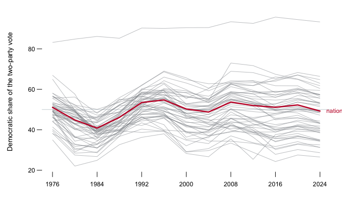

**Figure 1. The whole dataset, drawn conventionally.** Every state is a grey line on one shared pair of axes, with the country in red. One shared axis is the right form when the question is about one line, and this question is about fifty-one: move the pointer and only one state at a time becomes readable.

Nothing about this figure is wrong and almost nothing can be read from it. The national line is legible because it is the only one coloured. The rest form a band whose thickness carries no information anyone can extract. The failure is not density. **It is that every line is drawn in the same place.** Fifty-one series share one pair of axes, so the ink of one lands on the ink of another, and the comparison the figure was made for is the one it prevents.

Now the same numbers, one row each.

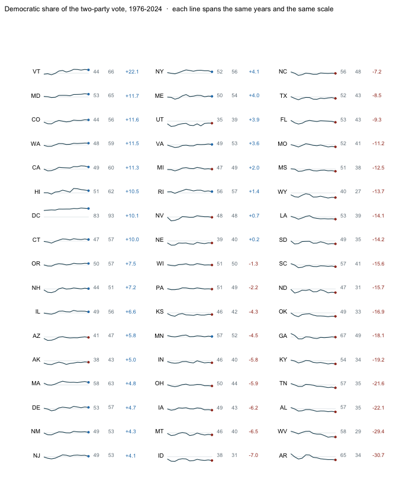

**Figure 2. The same 663 numbers as a table of sparklines, one row per state.** Every line covers the same years on the same vertical scale, so the shapes can be compared. The faint line inside each is 50%. The dot is the last election, coloured by which side it fell on, and the three numbers are where the state began, where it ended, and the difference.

Now grade your two states. **VT moved +22.1 points**, from 44.3% to 66.4%. **AR moved -30.7**, from 65.0% to 34.3%. Both sit at the ends of the table when it is sorted by change, and neither was findable in Figure 1.

Nothing was added to get here. The same numbers are on the page, given **one row each instead of one axis between them**. The axes have been thrown away because at this size they would take more room than the data. A sparkline cannot tell you what share MN held in any given year — for that there is a column of numbers beside it, which is what a table is for. It tells you the *shape*, and shape is what fifty-one overlapping lines destroyed.

The two ends of the table are the answer to the opening question. In 1976, AR was one of the most Democratic states on the page, at 65.0%, while VT sat below half, at 44.3%. Over thirteen elections they passed each other going opposite ways. No sentence about “the country” moving contains both of those rows, and the table holds forty-nine more, each with its own shape.

That said, the national tide is real, and the table can mislead a reader who forgets it. The country’s own share runs from **40.8% in 1984 to 54.7% in 1996**, a swing of 13.9 points that every state feels at once. Take any two consecutive elections in this series and count the states that moved the same way the country did: in the typical pair — the median of the 12 pairs — **89.2% of states move in the same direction as the country**, and in the least uniform pair it is still 60.8%.

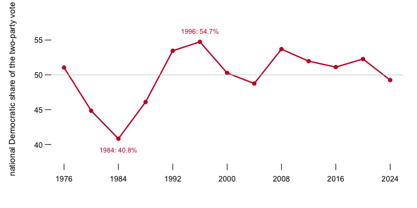

So most of the wiggle in most of those sparklines is not the state; it is the year. The button marked *show against the national* redraws each line as the state’s distance from the country, which holds the year constant and leaves only what is particular to the place. The subtraction is simple. In 1976, AR stood at 65.0% while the country stood at 51.0%, so its distance from the country was +14.0 points; in 2024 it stood at 34.3% against a national 49.2%, a distance of -14.9. Its relative change is the second distance minus the first, -28.9 points, against a raw change of -30.7: almost none of that fall was the country’s doing. Most of the lines go flat under this treatment. The exceptions are the realignments: AR still falls -28.9 points relative to the country, because that is a state changing sides rather than a state riding a national tide.

The flatness has its own message. 11 of the 51 rows never changed which party they backed in 13 elections, which is a fact about how much of the electoral map is settled before any campaign begins. GA changed sides 5 times, more than any other row on the table.

## What this brief cannot tell you

**A sparkline has no axis, so it cannot be read for a value.** That is the trade, not an oversight. Every quantity a reader might want to *read* is in a column beside the line; the line carries only the shape. A sparkline used without those columns is decoration.

**One scale, or fifty-one?** Every line here is drawn on the same vertical scale, which is what makes the shapes comparable and what makes the flattest rows genuinely flat. Scaling each row to its own range is the default in most software that draws these. It would make MN, whose whole range is 9.3 points, look exactly as dramatic as AR, whose range is 30.7. That default is the commonest way to get this figure wrong.

**States are not people and they are not equally sized.** Every row has the same height and the same weight in the eye, and the rows are nowhere near the same size in voters. A reader who takes an impression of “the country” from the number of rising and falling rows has counted states rather than people.

**The two-party share hides everyone else.** Perot’s 18.9% in 1992 disappears from this brief by construction, and so does every other third-party vote. A rise in the Democratic share of the two-party vote is not the same thing as a rise in Democratic votes.

## What you should have learned

- The states do not move as one: between 1976 and 2024, VT moved +22.1 points toward the Democrats while AR moved -30.7 the other way, and no national line contains both.
- The national tide is real all the same: a median of 89.2% of states move in the country’s direction between consecutive elections, so most of a state’s wiggle is the year, not the place.
- Subtracting the national movement flattens most rows; what survives, like AR’s -28.9-point relative fall, is realignment rather than tide.
- 11 of the 51 rows never changed sides across 13 elections; GA changed 5 times, more than any other.
- A sparkline trades the value for the shape: with no axis it cannot be read for a number, so it earns its place only inside a table that prints the numbers beside it.

## Extensions

None of these is answered above, and every one can be answered by sorting or filtering the tables the Sources section hands over.

- `states.csv` has `rel_change`, each state’s move with the national swing taken out. Sort it. Which states moved against the national tide, and are they the same states Figure 2’s sort by raw `change` puts at the ends?
- `states.csv` counts `flips` for every state. Find the rows where it is zero. Looking at their `first` and `last` columns, are they safe for one party, or just never examined closely?
- `series.csv` has both `two` and `rel` for every state and year. Pick one state and plot both columns. How different is the story once the national swing is taken out?
- Compare `range` against `change` in `states.csv`. Find a state that wandered a long way but ended near where it started. What would its sparkline look like, and what would its `change` number hide?

Two stretch ideas point past the spreadsheet. The historical-campaigns brief holds state returns long before 1976; extend one state’s series back a century and see whether its modern shape is new. And a sparkline table works for any set of parallel series: download one state’s governor results from its Secretary of State and set that sparkline beside its presidential row.

## Sources

**Data**

- Presidential vote by state and nationally, 1976–2024, from this book’s historical-campaigns brief, which describes the compilation it was built from and the repairs it needed. The figures here read that chapter’s published tables. The compilation is Jason Timm’s *PresElectionResults*, built from official state returns. https://github.com/jaytimm/PresElectionResults
- The three small tables below are derived from the historical-campaigns tables and nothing else. Every number above is computed from them when the page is rendered; nothing is typed in.

**Method**

- Tufte, Edward R. (2006). *Beautiful Evidence.* Graphics Press. ISBN 978-0961392177. Chapter 2 names and defines the sparkline. https://openlibrary.org/isbn/0961392177

**The data itself**

Every figure above is drawn from these tables. They are plain CSV, they open in a spreadsheet, and they are yours to take further.

`national.csv`, `series.csv`, `states.csv`, `pres_national.csv`

One more file is not data about the subject – it is how this chapter checked its own numbers: `facts.csv`, the individual numbers the text above quotes.

[^1]: Edward R. Tufte, *Beautiful Evidence* (Cheshire, Conn.: Graphics Press, 2006), chapter 2, “Sparklines: Intense, Simple, Word-Sized Graphics,” https://openlibrary.org/isbn/0961392177.